# RWFD: CALL CENTER OPERATIONS DATA

The purpose of this notebook is to investigate the call center operations dataset. I will be conducting several analyses to help me prepare to buidling multiple statistical models. My hope is that this EDA will provide me with enough information to know the distribution of the data, the correlation and variability between columns.

## Importing libraries

```python
import numpy as np
import pandas as pd
import seaborn as sns
import matplotlib.pyplot as plt
```

# Loading the dataset

```python
call_center_data = pd.read_csv('/home/andi/Documents/RWDF/Call center/synthetic_call_center_data.csv')
call_center_data.head()
```

|  | Call ID | Timestamp | Call Type | Call Duration (min) | Call Reason | Resolution Status | CSAT Score | First Call Resolution | Agent ID | Agent Name | ... | Contact Channel | Day of Week | Hour of Day | Queue Wait Time (min) | Call Transfer Count | Sentiment Score | Escalation Level | Callback Requested | Dropped Call | Hold Time (min) |
| --- | --- | --- | --- | --- | --- | --- | --- | --- | --- | --- | --- | --- | --- | --- | --- | --- | --- | --- | --- | --- | --- |
| 0 | b5f9dd7f-26e2-4ec1-ba60-a186f29cd081 | 2024-08-28 02:00:00 | Inbound | 4 | Billing Issue | Resolved | 10 | False | c25f5241-e18e-4d68-b7d6-a8764ad2a900 | Christina Harper | ... | Phone | Wednesday | 2 | 6 | 0 | 0.52 | Tier 1 | False | False | 18 |
| 1 | 64297359-bfb8-488b-8819-612219ea4b38 | 2024-03-23 20:00:00 | Inbound | 1 | Contract Termination | Resolved | 8 | True | a72110b7-abaf-4812-a8b2-5c8d36839de9 | Crystal Carlson | ... | WhatsApp | Saturday | 20 | 4 | 0 | 0.96 | Tier 1 | False | False | 3 |
| 2 | ec4c2dc8-80a2-40a2-b7e0-678bab0c0cac | 2024-05-07 20:00:00 | Inbound | 2 | App Issue | Resolved | 9 | True | 83578890-b40d-4401-8a36-5598a773abd5 | Paul Thompson | ... | WhatsApp | Tuesday | 20 | 13 | 0 | 0.24 | Tier 1 | False | False | 5 |
| 3 | 3f87d746-39cf-4aae-b797-ac9d181b18a6 | 2024-01-30 15:00:00 | Inbound | 1 | Overcharge | Resolved | 10 | True | ff6bdbcb-b470-439d-bb01-81bb39738f3e | Christina Sims | ... | App | Tuesday | 15 | 0 | 0 | 0.12 | Tier 1 | False | False | 11 |
| 4 | e2df4b9a-c97b-407b-86a6-8e4cea25fc37 | 2024-06-19 13:00:00 | Inbound | 8 | Setup Help | Resolved | 1 | False | 177f7ee3-4b57-4baa-b5ab-9a1a99812201 | Andrew Myers | ... | Web | Wednesday | 13 | 14 | 0 | 0.21 | Tier 1 | False | False | 9 |

5 rows × 28 columns

```python
print(f'The shape of the data is: {call_center_data.shape}')
```

```
The shape of the data is: (100000, 28)
```

```python
call_center_data.info()
```

```
<class 'pandas.core.frame.DataFrame'>
RangeIndex: 100000 entries, 0 to 99999
Data columns (total 28 columns):
 #   Column                 Non-Null Count   Dtype
---  ------                 --------------   -----
 0   Call ID                100000 non-null  object
 1   Timestamp              100000 non-null  object
 2   Call Type              100000 non-null  object
 3   Call Duration (min)    100000 non-null  int64
 4   Call Reason            100000 non-null  object
 5   Resolution Status      100000 non-null  object
 6   CSAT Score             100000 non-null  int64
 7   First Call Resolution  100000 non-null  bool
 8   Agent ID               100000 non-null  object
 9   Agent Name             100000 non-null  object
```

[output cut: 20 more lines]

## Data Cleaning

The column `Timestamp` is not the expected datetime type. I will convert it using pandas `to_datetime`.

```python
call_center_data['Timestamp'] = pd.to_datetime(call_center_data['Timestamp'])
call_center_data.info()
```

```
<class 'pandas.core.frame.DataFrame'>
RangeIndex: 100000 entries, 0 to 99999
Data columns (total 28 columns):
 #   Column                 Non-Null Count   Dtype
---  ------                 --------------   -----
 0   Call ID                100000 non-null  object
 1   Timestamp              100000 non-null  datetime64[ns]
 2   Call Type              100000 non-null  object
 3   Call Duration (min)    100000 non-null  int64
 4   Call Reason            100000 non-null  object
 5   Resolution Status      100000 non-null  object
 6   CSAT Score             100000 non-null  int64
 7   First Call Resolution  100000 non-null  bool
 8   Agent ID               100000 non-null  object
 9   Agent Name             100000 non-null  object
```

[output cut: 20 more lines]

```python
call_center_data.isna().sum()
```

```
Call ID                  0
Timestamp                0
Call Type                0
Call Duration (min)      0
Call Reason              0
Resolution Status        0
CSAT Score               0
First Call Resolution    0
Agent ID                 0
Agent Name               0
Agent Tenure (months)    0
Skill Level              0
Languages                0
Team                     0
Customer ID              0
Customer Location        0
Customer Type            0
Account Age (days)       0
Contact Channel          0
Day of Week              0
Hour of Day              0
Queue Wait Time (min)    0
Call Transfer Count      0
Sentiment Score          0
Escalation Level         0
Callback Requested       0
Dropped Call             0
Hold Time (min)          0
dtype: int64
```

```python
if call_center_data.duplicated().sum() == 0:
    print(f'There are no duplicated calls')
else:
    print(call_center_data.duplicated().sum())
```

```
There are no duplicated calls
```

```python
call_center_data.describe()
```

|  | Timestamp | Call Duration (min) | CSAT Score | Agent Tenure (months) | Account Age (days) | Hour of Day | Queue Wait Time (min) | Call Transfer Count | Sentiment Score | Hold Time (min) |
| --- | --- | --- | --- | --- | --- | --- | --- | --- | --- | --- |
| count | 100000 | 100000.000000 | 100000.000000 | 100000.000000 | 100000.000000 | 100000.000000 | 100000.000000 | 100000.000000 | 100000.000000 | 100000.000000 |
| mean | 2024-07-05 07:39:01.368000 | 8.484020 | 6.879370 | 30.507360 | 501.545890 | 11.537900 | 3.504900 | 0.222510 | 0.117538 | 5.737890 |
| min | 2024-01-01 00:00:00 | 1.000000 | 1.000000 | 1.000000 | 1.000000 | 0.000000 | 0.000000 | 0.000000 | -1.000000 | 0.000000 |
| 25% | 2024-04-03 20:00:00 | 3.000000 | 5.000000 | 15.000000 | 250.000000 | 6.000000 | 0.000000 | 0.000000 | -0.230000 | 2.000000 |
| 50% | 2024-07-05 10:00:00 | 6.000000 | 7.000000 | 30.000000 | 502.000000 | 12.000000 | 0.000000 | 0.000000 | 0.130000 | 5.000000 |
| 75% | 2024-10-07 17:00:00 | 12.000000 | 9.000000 | 46.000000 | 753.000000 | 18.000000 | 7.000000 | 0.000000 | 0.480000 | 8.000000 |
| max | 2024-12-31 00:00:00 | 85.000000 | 10.000000 | 60.000000 | 1000.000000 | 23.000000 | 14.000000 | 2.000000 | 1.000000 | 19.000000 |
| std | NaN | 7.983308 | 2.688857 | 17.335386 | 289.103281 | 6.931505 | 4.653598 | 0.565723 | 0.499622 | 4.388872 |

- The data holds call records for the entire year of 2024.
- A call can last anywhere between 1 minute to 85 minutes.
- There is a 5 minute difference between the max wait time and hold time.

```python
call_center_data.nunique()
```

```
Call ID                  100000
Timestamp                  8761
Call Type                     2
Call Duration (min)          77
Call Reason                  13
Resolution Status             2
CSAT Score                   10
First Call Resolution         2
Agent ID                 100000
Agent Name                71103
Agent Tenure (months)        60
Skill Level                   3
Languages                    16
Team                          5
Customer ID              100000
Customer Location         38132
Customer Type                 3
Account Age (days)         1000
Contact Channel               4
Day of Week                   7
Hour of Day                  24
Queue Wait Time (min)        15
Call Transfer Count           3
Sentiment Score             201
Escalation Level              3
Callback Requested            2
Dropped Call                  2
Hold Time (min)              20
dtype: int64
```

The column `Agent ID` is a unique identifier applied to each agent per call, hence there are 100000 `Agent ID` and 71103 `Agent Name`

Now that I have the summary statistics of the numeric columns, I will move on to plotting visualisations of various columns and their relationships. The first step is to look at customer support agent statistics: `Skill Level`, `Agent Tenure`, `Team`

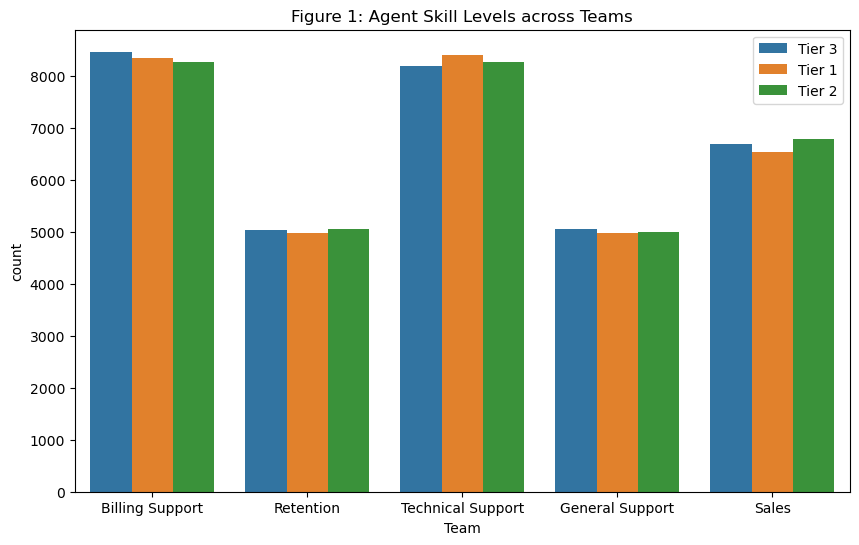

```python
plt.figure(figsize=(10,6))
sns.countplot(data=call_center_data, x='Team', hue='Skill Level')
plt.title('Figure 1: Agent Skill Levels across Teams')
plt.xlabel('Team')
plt.legend()
plt.show()
```

The bar graph in Figure 1 shows that each team has agents at all experience levels. Moreover, Billing and Technical Support have more agents than other teams.

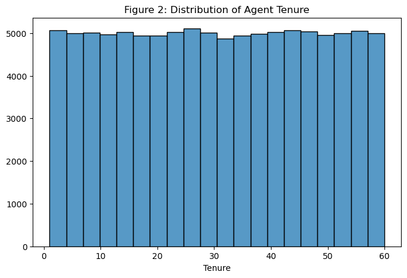

```python
plt.figure(figsize=(8,5))
sns.histplot(data=call_center_data['Agent Tenure (months)'], bins=20)
plt.title('Figure 2: Distribution of Agent Tenure')
plt.xlabel('Tenure')
plt.ylabel('')
plt.show()
```

Figure 2 shows a uniform distribution of tenure.

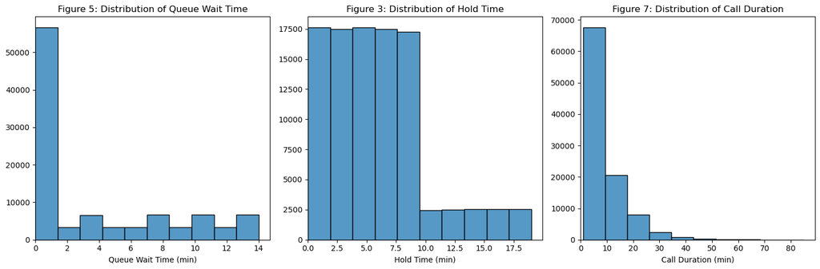

```python
fig, axes = plt.subplots(1, 3, figsize=(15, 5))

sns.histplot(data=call_center_data['Queue Wait Time (min)'], bins=10, ax=axes[0])

axes[0].set_title('Figure 5: Distribution of Queue Wait Time')
axes[0].set_ylabel('')
axes[0].set_xlim(left=0)

sns.histplot(data=call_center_data['Hold Time (min)'], bins=10, ax=axes[1] )

axes[1].set_title('Figure 3: Distribution of Hold Time')
axes[1].set_ylabel('')
axes[1].set_xlim(left=0)

sns.histplot(data=call_center_data['Call Duration (min)'],bins=10, ax=axes[2])

axes[2].set_title('Figure 7: Distribution of Call Duration')
axes[2].set_ylabel('')
axes[2].set_xlim(left=0)

plt.tight_layout()
plt.show()
```

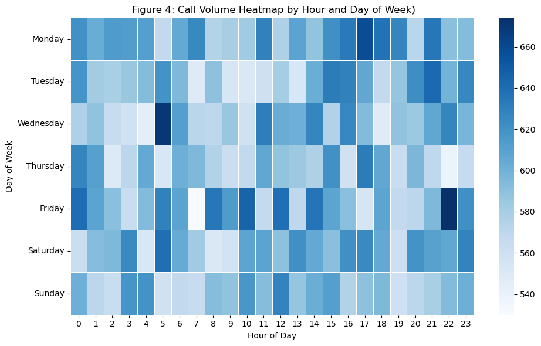

```python
dow_order = ['Monday', 'Tuesday', 'Wednesday','Thursday', 'Friday', 'Saturday', 'Sunday']

pivoted_data = (call_center_data.pivot_table(index='Day of Week', columns='Hour of Day', values='Call ID', aggfunc='count').reindex(dow_order))

plt.figure(figsize=(10, 6))

sns.heatmap(pivoted_data, cmap='Blues',linewidths=0.5,linecolor='white')

plt.title(' Figure 4: Call Volume Heatmap by Hour and Day of Week)')
plt.xlabel('Hour of Day')
plt.ylabel('Day of Week')

plt.tight_layout()
plt.show()
```

```python
resolution_crosstab = pd.crosstab(columns=[call_center_data['Escalation Level'], call_center_data['Resolution Status']], index=[call_center_data['Call Transfer Count'], call_center_data['First Call Resolution']], margins=True)
display(resolution_crosstab)
```

| Call Transfer Count | Escalation Level Resolution Status First Call Resolution | Tier 1 Resolved | Tier 2 Escalated | Tier 3 Escalated | All |
| --- | --- | --- | --- | --- | --- |
| 0 | False | 21224 | 0 | 0 | 21224 |
|  | True | 63877 | 0 | 0 | 63877 |
| 1 | False | 0 | 881 | 898 | 1779 |
|  | True | 0 | 2859 | 2909 | 5768 |
| 2 | False | 0 | 900 | 911 | 1811 |
|  | True | 0 | 2755 | 2786 | 5541 |
| All |  | 85101 | 7395 | 7504 | 100000 |

The cross table above shows that there are:

- 3 levels of escalation that apply to call resolution status. all resolved calls are marked as with Tier 1 escalation level.
- Zero transfers are a strong predictor of Tier 1 resolution and successful handling.
- Any call transfer over 0 guarantees escalation beyond Tier 1.

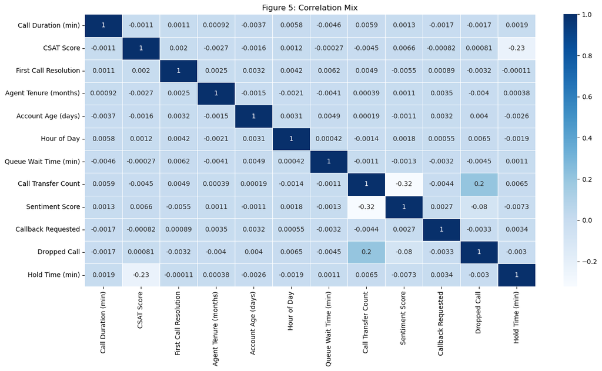

```python
corr_mix = call_center_data.corr(numeric_only=True)

plt.figure(figsize=(14,8))
sns.heatmap(corr_mix, cmap='Blues',linewidths=0.5,linecolor='white', annot=True)
plt.title('Figure 5: Correlation Mix')
plt.tight_layout()
plt.show()
```

```python
display(corr_mix)
```

|  | Call Duration (min) | CSAT Score | First Call Resolution | Agent Tenure (months) | Account Age (days) | Hour of Day | Queue Wait Time (min) | Call Transfer Count | Sentiment Score | Callback Requested | Dropped Call | Hold Time (min) |
| --- | --- | --- | --- | --- | --- | --- | --- | --- | --- | --- | --- | --- |
| Call Duration (min) | 1.000000 | -0.001126 | 0.001098 | 0.000923 | -0.003652 | 0.005803 | -0.004644 | 0.005870 | 0.001315 | -0.001676 | -0.001712 | 0.001922 |
| CSAT Score | -0.001126 | 1.000000 | 0.001978 | -0.002746 | -0.001569 | 0.001153 | -0.000269 | -0.004509 | 0.006604 | -0.000818 | 0.000809 | -0.228627 |
| First Call Resolution | 0.001098 | 0.001978 | 1.000000 | 0.002496 | 0.003215 | 0.004163 | 0.006177 | 0.004926 | -0.005547 | 0.000891 | -0.003173 | -0.000105 |
| Agent Tenure (months) | 0.000923 | -0.002746 | 0.002496 | 1.000000 | -0.001540 | -0.002071 | -0.004135 | 0.000394 | 0.001126 | 0.003530 | -0.003991 | 0.000380 |
| Account Age (days) | -0.003652 | -0.001569 | 0.003215 | -0.001540 | 1.000000 | 0.003116 | 0.004918 | 0.000194 | -0.001080 | 0.003234 | 0.003953 | -0.002552 |
| Hour of Day | 0.005803 | 0.001153 | 0.004163 | -0.002071 | 0.003116 | 1.000000 | 0.000417 | -0.001428 | 0.001822 | 0.000547 | 0.006539 | -0.001932 |
| Queue Wait Time (min) | -0.004644 | -0.000269 | 0.006177 | -0.004135 | 0.004918 | 0.000417 | 1.000000 | -0.001126 | -0.001293 | -0.003179 | -0.004466 | 0.001128 |
| Call Transfer Count | 0.005870 | -0.004509 | 0.004926 | 0.000394 | 0.000194 | -0.001428 | -0.001126 | 1.000000 | -0.321364 | -0.004399 | 0.202755 | 0.006497 |
| Sentiment Score | 0.001315 | 0.006604 | -0.005547 | 0.001126 | -0.001080 | 0.001822 | -0.001293 | -0.321364 | 1.000000 | 0.002676 | -0.079917 | -0.007319 |
| Callback Requested | -0.001676 | -0.000818 | 0.000891 | 0.003530 | 0.003234 | 0.000547 | -0.003179 | -0.004399 | 0.002676 | 1.000000 | -0.003255 | 0.003423 |
| Dropped Call | -0.001712 | 0.000809 | -0.003173 | -0.003991 | 0.003953 | 0.006539 | -0.004466 | 0.202755 | -0.079917 | -0.003255 | 1.000000 | -0.002994 |
| Hold Time (min) | 0.001922 | -0.228627 | -0.000105 | 0.000380 | -0.002552 | -0.001932 | 0.001128 | 0.006497 | -0.007319 | 0.003423 | -0.002994 | 1.000000 |

call_center_data.to_csv('call_center_clean.csv', index=False)